# Rap Artists

Earlier this year, BBC Music asked more than 100 critics, artists, and other music industry folks from 15 countries for their five favorite hip-hop tracks. Then they broke down the results of the poll into one definitive list. But BBC Music didn’t just publish a best-of list, they also published the complete poll results and a description of the simple algorithm they ranked the songs with. - Simon Jockers

We awarded 10 points for first ranked track, eight points for second ranked track, and so on down to two points for fifth place. The song with the most points won. We split ties by the total number of votes: songs with more votes ranked higher. Any ties remaining after this were split by first place votes, followed by second place votes and so on: songs with more critics placing them at higher up the lists up ranked higher. – BBC Music

```
Observations: 311
Variables: 12
$ ID     <dbl> 1, 2, 3, 4, 5, 6, 7, 8, 9, 10, 11, 12, 13, 14, 15, 16, 17, 18,…
$ title  <chr> "Juicy", "Fight The Power", "Shook Ones (Part II)", "The Messa…
$ artist <chr> "The Notorious B.I.G.", "Public Enemy", "Mobb Deep", "Grandmas…
$ year   <dbl> 1994, 1989, 1995, 1982, 1992, 1993, 1993, 1992, 1994, 1995, 20…
$ gender <chr> "male", "male", "male", "male", "male", "male", "male", "male"…
$ points <dbl> 140, 100, 94, 90, 84, 62, 50, 48, 46, 42, 38, 36, 36, 34, 32, …
$ n      <dbl> 18, 11, 13, 14, 14, 10, 7, 6, 7, 6, 5, 5, 4, 6, 5, 5, 4, 5, 5,…
$ n1     <dbl> 9, 7, 4, 5, 2, 3, 2, 3, 1, 2, 2, 1, 2, 1, 1, 0, 2, 2, 1, 1, 1,…
$ n2     <dbl> 3, 3, 5, 3, 4, 1, 2, 2, 3, 1, 0, 1, 2, 0, 1, 3, 1, 0, 1, 1, 1,…
$ n3     <dbl> 3, 1, 1, 1, 2, 1, 2, 0, 1, 1, 3, 3, 0, 2, 2, 1, 0, 1, 1, 1, 0,…
$ n4     <dbl> 1, 0, 1, 0, 4, 4, 0, 0, 1, 2, 0, 0, 0, 3, 0, 0, 1, 0, 1, 0, 2,…
$ n5     <dbl> 2, 0, 2, 5, 2, 1, 1, 1, 1, 0, 0, 0, 0, 0, 1, 1, 0, 2, 1, 2, 1,…
```

## Which eras are represented most in Critic’s Top 5 Picks?

First, let’s see how much data we have for tracks as a function of year.

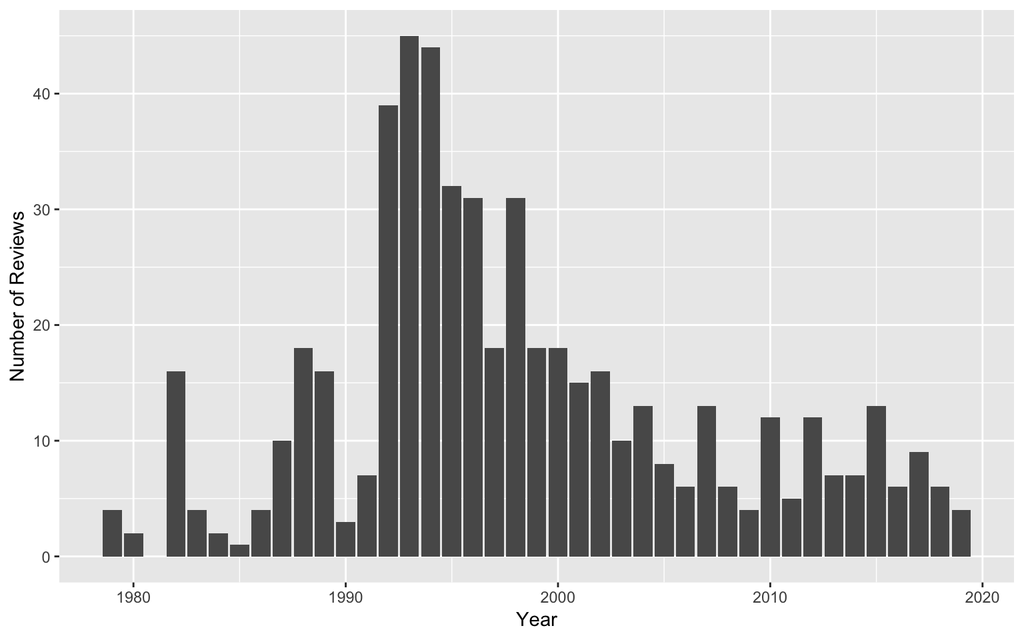

It seems reasonable to create 5-year bins

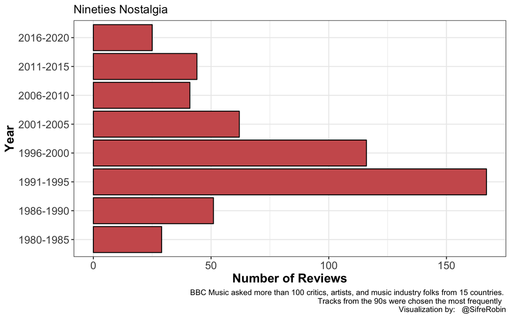

We can see that the 90’s are over-represented here. #Nostalgia.

# Which tracks were selected the most?

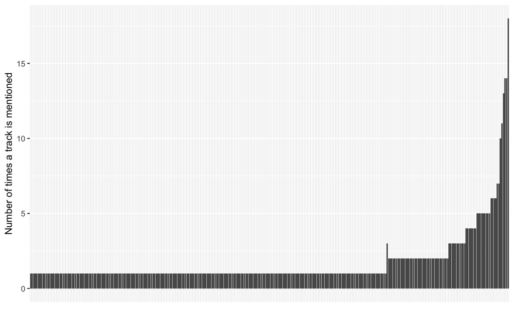

A number of tracks are only mentioned once. Let’s focus on which tracks were mentioned at least 5 times.

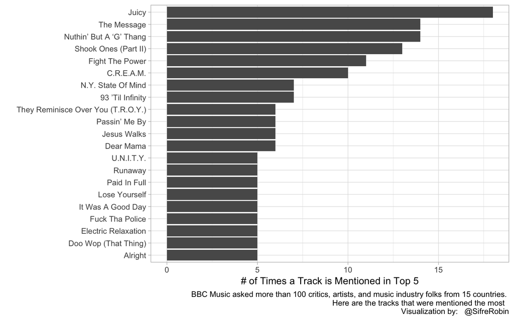

```
# A tibble: 9 x 5
  points title                  artist                            year years_bin
   <dbl> <chr>                  <chr>                            <dbl> <ord>
1    140 Juicy                  The Notorious B.I.G.              1994 1991-1995
2    100 Fight The Power        Public Enemy                      1989 1986-1990
3     90 The Message            Grandmaster Flash & The Furious…  1982 1980-1985
4     38 Runaway                Kanye West ft. Pusha T            2010 2006-2010
5     32 B.O.B.                 OutKast                           2000 1996-2000
6     28 Lose Yourself          Eminem                            2002 2001-2005
7     22 Alright                Kendrick Lamar                    2015 2011-2015
8     10 Bodak Yellow           Cardi B                           2017 2016-2020
9     10 How To Rap About Afri… Black Vulcanite                   2016 2016-2020
```

# What were the top tracks across time??

```
# A tibble: 8 x 4
# Groups:   years_bin [8]
  title                artist                               years_bin n_reviews
  <chr>                <chr>                                <ord>         <int>
1 Alright              Kendrick Lamar                       2011-2015         5
2 Bodak Yellow         Cardi B                              2016-2020         2
3 Doo Wop (That Thing) Lauryn Hill                          1996-2000         5
4 Fight The Power      Public Enemy                         1986-1990        11
5 Jesus Walks          Kanye West                           2001-2005         6
6 Juicy                The Notorious B.I.G.                 1991-1995        18
7 Runaway              Kanye West ft. Pusha T               2006-2010         5
8 The Message          Grandmaster Flash & The Furious Five 1980-1985        14
```

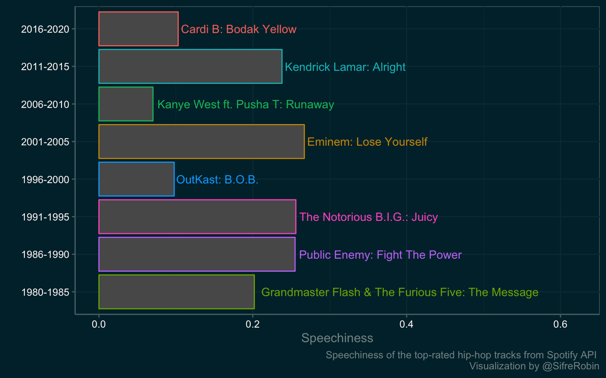

[figure not shown]

2020-04-15